# geneBasis, spleen.

Alsu Missarova

8 June 2021

#### Package

geneBasisR 0.0.0.9000

```r
library(geneBasisR)
library(SingleCellExperiment)
```

```r
library(tibble)
library(ggplot2)
library(ggpubr)
library(knitr)
library(reshape2)
```

# 1 Introduction

`geneBasis` is an iterative greedy approach for gene selection. It strives a gene selection that will preserve transcriptional relationships between cells, represented as kNN-graphs.

Here we exemplify how `geneBasis` can be utilized for library design. As an input, we use raw .txt files containing counts and metadata.

First, we design a library of designated size from scratch and using an initial selection. We then compare two libraries at cell type, cell and gene score levels.

# 2 Load data

We will be working with adult human spleen. Log-counts and meta file are stored as .txt files, and we will use the function `raw_to_sce` to transform it to the right format (SingleCellExperiment object).

We performed initial selection for genes and retained only first 3000 highly variable genes (solely to decrease memory usage), but we will nevertheless introduce how to pre-select features using `retain_informative_genes` (but since we already did the selection for HVGs, we set `select.hvgs = FALSE`).

```r
# note that we saved logcounts already. If you work with counts, specify it in 'counts_type'
counts_dir = system.file("extdata", "raw_spleen.txt", package = "geneBasisR")
meta_dir = system.file("extdata", "raw_spleen_meta.txt", package = "geneBasisR")

sce_spleen = raw_to_sce(counts_dir = counts_dir, counts_type = "logcounts", transform_counts_to_logcounts = FALSE, header = TRUE, sep = "\t" , meta_dir = meta_dir, batch = NULL)
meta_spleen = as.data.frame(colData(sce_spleen))

sce_spleen = retain_informative_genes(sce_spleen, select.hvgs = FALSE, discard.mt = TRUE)
```

```
#> 2997 genes retained
```

```r
# let's print out cell type composition
tab = as.data.frame(table(sce_spleen$celltype))
colnames(tab) = c("celltype", "n")
tab = tab[order(tab$n),]
kable(tab , caption = "Cell type composition" )
```

Table 1: Cell type composition

|  | celltype | n |
| --- | --- | --- |
| 7 | Fibroblast | 11 |
| 3 | DC1 | 13 |
| 9 | HSC | 29 |
| 10 | ILC | 34 |
| 16 | Plasmablast | 41 |
| 6 | Ery | 44 |
| 15 | Plasma cell | 114 |
| 5 | EC | 118 |
| 4 | DC2 | 126 |
| 11 | Mac | 198 |
| 14 | NK | 201 |
| 1 | CD4+ T | 208 |
| 2 | CD8+ T | 255 |
| 13 | MZ B | 320 |
| 8 | Follicular B | 324 |
| 12 | Monocyte | 561 |

# 3 Select and compare libraries

## 3.1 geneBasis

We will precompute intermediate stat we will need for the run using `calc_Minkowski_distances`.

It is not essential and will be computed automatically, if you set `stat_all = NULL` in `gene_search` (default option). The user-case where it is beneficial to precompute intermediate stat is when multiple libraries are sought to be selected and this stat can be recycled. Also note that to set the colnames correctly (see example below).

```r
stat_all = calc_Minkowski_distances(sce_spleen , genes = rownames(sce_spleen))
colnames(stat_all) = c("gene" , "dist_all")

genes_stat = gene_search(sce_spleen , n_genes_total = 25, stat_all = stat_all , verbose = F)
genes_geneBasis = genes_stat$gene
```

## 3.2 Manually selected

As a control, we manually picked 1-2 markers for each cell type that were used for cell type annotation.

```r
genes_manual = c("IL7R", "CD3D", "KLRD1", "IFITM1", "C1QA" , "C1QB" , "CST3" , "CD74" , "CCL14" , "TIMP3" ,
               "HBB", "HBA2", "IGFBP7", "CXCL13" , "CD37" , "TCL1A", "GSTM3" , "AREG" , "LRRC75A" ,
               "GNLY" , "APOE" , "S100A9" , "CD27" , "GZMB" , "IGKC")
```

# 4 Comparison between libraries

## 4.1 Cell type mapping

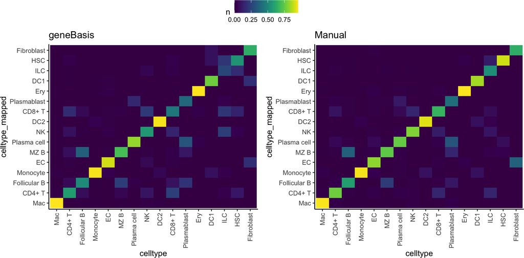

Figure 1: Cell type confusion matrices

```r
mapping_geneBasis = get_celltype_mapping(sce_spleen, genes_geneBasis)
mapping_manual = get_celltype_mapping(sce_spleen, genes_manual)


p1 = plot_mapping_heatmap(mapping_geneBasis$mapping) + ggtitle("geneBasis")
p2 = plot_mapping_heatmap(mapping_manual$mapping) + ggtitle("Manual")
p = ggarrange(p1,p2, common.legend = T)
p
```

Overall, we see that we select genes that resolve cell types to a similar degree than manually curated and selected markers.

Let’s perform a quantitative per cell type comparison.

## 4.2 Quantitative comparison

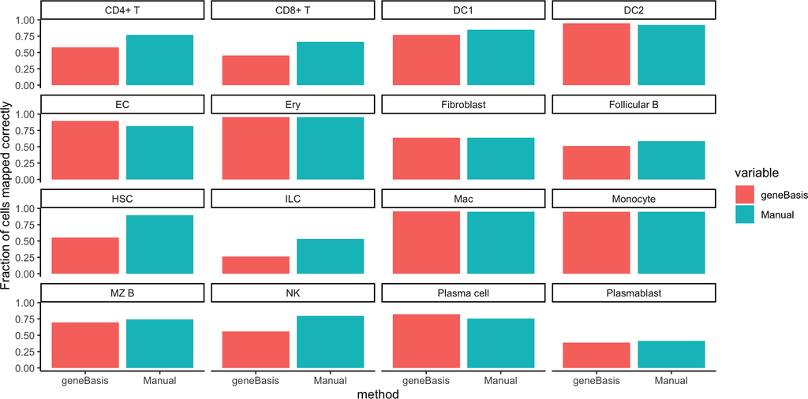

Figure 2: Quantitatice comparison between cell type mappings

```r
mapping_geneBasis = mapping_geneBasis$stat
colnames(mapping_geneBasis) = c("celltype" , "geneBasis")

mapping_manual = mapping_manual$stat
colnames(mapping_manual) = c("celltype" , "Manual")

mapping = merge(mapping_geneBasis, mapping_manual)
mapping = melt(mapping, id = "celltype")


p = ggplot(mapping , aes(x = variable , y = value , fill = variable)) +
  geom_bar(stat = "identity", position = "dodge") +
  facet_wrap(~celltype) +
  theme_classic() +
  labs(x = "method" , y = "Fraction of cells mapped correctly")
p
```

## 4.3 Cell neighborhood preservation score (aka cell score)

Now, let’s assess how well we preserve cell neighborhoods.

We can calculate cell score for each library using `get_neighborhood_preservation_scores`.

We will also precompute intermediate variable `neighs.all` (using `get_z_scaled_distances`) since it will be recycled (note that this is optional, `get_neighborhood_preservation_scores` can compute it automatically if default settings).

```r
# we calculate neighs.all because we will recycle it
neighs.all = get_z_scaled_distances(sce_spleen)

# cell score - geneBasis selection
cellScore_geneBasis = get_neighborhood_preservation_scores(sce_spleen, neighs.all = neighs.all, genes.selection = genes_geneBasis)
colnames(cellScore_geneBasis) = c("cell_score_geneBasis", "cell")

# cell score - manual selection
cellScore_manual = get_neighborhood_preservation_scores(sce_spleen, neighs.all = neighs.all, genes.selection = genes_manual)
```

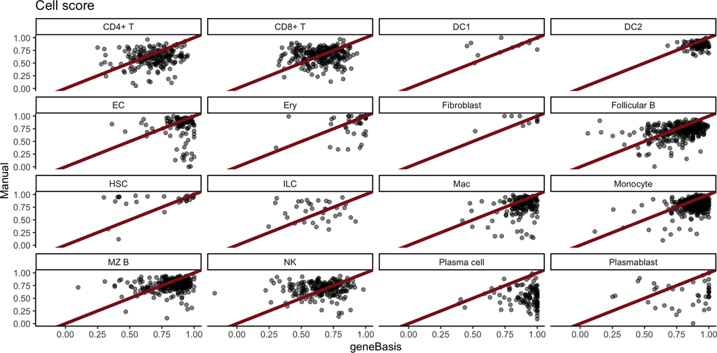

Figure 3: Cell score comparison

```r
colnames(cellScore_manual) = c("cell_score_manual", "cell")

# combine together
cellScore = merge(cellScore_geneBasis, cellScore_manual)
cellScore = merge(cellScore, meta_spleen)

p = ggplot(cellScore, aes(x = cell_score_geneBasis , y = cell_score_manual)) +
  geom_point(alpha = .5) +
  geom_abline(slope=1, color = "firebrick4", size = 1.5) +
  facet_wrap(~celltype) +
  theme_classic() +
  ylim(c(0,1)) +
  labs(x = "geneBasis" , y = "Manual") +
  ggtitle("Cell score")
p
```

Overall, we observe that two selections either preserve cell neighborhoods comparably or geneBasis preserves it better for some cell types (e.g. Plasma cells, Plasmablasts, Endothelium cells (EC)).

## 4.4 Gene prediction score (aka gene score)

Finally, let’s assess how well we explain transcriptome.

We can calculate cell score for each library using `get_gene_prediction_scores`.

We will also precompute intermediate variable `gene_stat_all` (using `get_gene_correlation_scores`) since it will be recycled (note that this is optional, `get_neighborhood_preservation_scores` can compute it automatically if default settings). If you plan to precompute this, do not forget to set right the colnames (see example below).

```r
# we calculate gene_stat_all because we will recycle it
gene_stat_all = get_gene_correlation_scores(sce_spleen, genes = rownames(sce_spleen), nPC = 50)


```

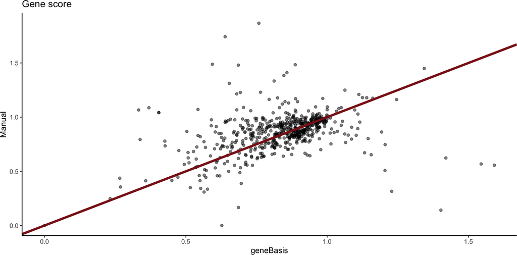

Figure 4: Gene score comparison

```r
colnames(gene_stat_all) = c("gene" , "corr_all")

# gene score - geneBasis selection
geneScore_geneBasis = get_gene_prediction_scores(sce_spleen, genes.selection = genes_geneBasis, gene_stat_all = gene_stat_all)
geneScore_geneBasis = geneScore_geneBasis[, c("gene", "gene_score")]
colnames(geneScore_geneBasis) = c("gene", "gene_score_geneBasis")

# gene score - manual selection
geneScore_manual = get_gene_prediction_scores(sce_spleen, genes.selection = genes_manual, gene_stat_all = gene_stat_all)
geneScore_manual = geneScore_manual[, c("gene", "gene_score")]
colnames(geneScore_manual) = c("gene", "gene_score_manual")

# combine together
geneScore = merge(geneScore_geneBasis, geneScore_manual)

p = ggplot(geneScore, aes(x = gene_score_geneBasis , y = gene_score_manual)) +
  geom_point(alpha = .5) +
  geom_abline(slope=1, color = "firebrick4", size = 1.5) +
  theme_classic() +
  labs(x = "geneBasis" , y = "Manual") +
  ggtitle("Gene score")
p
```

Overall, we see that we predict transcriptome to a similar degree. However, for both methods, there is a subset of genes predicted well with one selection but not the other. The downstream assessment of genes that are not predicted well is not a part of the package per se, however, we include several plotting functions to facilitate the analysis (exemplified in the Tutorial for Mouse embryo).